# Alcohol Consumption: At a Glance

## Project title

Alcohol Consumption: At a Glance

### Authors

Aaron Li, Evan Sun, Arvin Hakakian, Annie Chang

### Abstract

This study analyzes student alcohol consumption data to identify patterns and trends, employing statistical techniques and standard data visualizations. Key findings include the identification of high-risk groups and the influence of social and environmental factors on drinking behavior. The results provide valuable insights for developing targeted interventions and policies to promote responsible alcohol use among students.

### Keywords

Keywords: Alcohol Epidemiology; Universities and Colleges; Student Behavioral Factors; Population Health;

### Introduction

Navigating university comes with its own set of challenges, not least of which is the role that lifestyle choices play in a student’s academic performance, such as consumption of alcohol.

We aim to delve into how drinking impacts students in university in many different aspects of their life, and especially how it correlates with their personal, academic and social life. We’re motivated by a desire to understand and mitigate the potential negative effects of drinking on student success.

The questions that we came up with below are important because they address and inform us of the intersections of student behavior, academic disciplines, and personal backgrounds. For example, it’s important to know if students in certain majors tend to drink more and if that affects their grades. Also, this data, and the correlations within it, can help in making more effective educational and preventive strategies.

Here are the five research questions we will explore:

1. How does alcohol consumption correlate with the student’s major?
2. What impact does alcohol consumption have on students’ grades within each major?
3. How do parental attitudes and relationships influence a student’s drinking habits?
4. Is there a difference in drinking frequency between students who are on scholarships and those who are not?
5. How do living arrangements affect students’ alcohol consumption patterns?

These questions are designed to give us a comprehensive view of how alcohol consumption correlates with academic and social life of students, aiming to inform better support structures for students.

### Related Work

In a survey of almost eighteen-thousand students spread across 140 college campuses conducted in 1993, a team of researchers associated with the Harvard School of Public Health found that almost half(44%) of college students could be categorized as ‘binge drinkers’ [1]. This alarming discovery of excessive alcohol consumption among students shed light on a population health problem still plaguing campuses to this day. Further research has only revealed student alcohol consumption as a complex issue rooted in numerous factors, including social norms, religion, parental influence [2], and more. In fact, with the advent of technology in daily life, the problem has only become more complicated as recent studies point to a relationship between social media use and alcohol consumption [3]. With colleges continuing to accept newer generations onto their campuses, there will undoubtedly be new factors that arise in the problem of alcohol abuse. Thus it’s imperative that we focus on a holistic approach to mitigating the harms of the issue through informed statistical analysis and highlighting patterns with novel data visualizations. With that in mind, our plan for this project will be to build upon the ongoing effort by applying statistical analysis techniques and novel data visualizations to examine how known factors may interact/compound with each other to affect drinking behavior.

References:

1. Wechsler, H et al. “Health and behavioral consequences of binge drinking in college. A national survey of students at 140 campuses.” JAMA vol. 272,21 (1994): 1672-7.
2. Paschall, Mallie J, and Robert L Flewelling. “Postsecondary education and heavy drinking by young adults: the moderating effect of race.” Journal of studies on alcohol vol. 63,4 (2002): 447-55. doi:10.15288/jsa.2002.63.447
3. Moreno, Megan A, and Jennifer M Whitehill. “Influence of Social Media on Alcohol Use in Adolescents and Young Adults.” Alcohol research : current reviews vol. 36,1 (2014): 91-100.

### The Dataset

Dataset:

- Effects of Alcohol on Student Performance
- Who collected the data? Joshua Naude and Jordan Bendeman, students at Stellenbosch University’s Department of Statistics and Actuarial Science
- How was the data collected or generated? It was collected via a google form survey, then exported to csv.
- Why was the data collected? The authors wanted to predict sstudents academic performance using a multilinear regression model built on the predictors mentioned based on 2023 student information.
- How many observations (rows) are in your data? 406 observations
- How many features (columns) are in the data? 17 features
- What, if any, ethical questions or questions of power do you need to consider when working with this data? In working with this data, we will look to acknowledge how each entry represents a student with their own struggles against systemic, cultural, financial, and other disadvantages. Thus, we will try to clearly communicate that any findings or correlations in the data should not be used to predict, single out, or otherwise harass individuals. What are possible limitations or problems with this data? The first limitation with the data is that it describes a South African university, meaning that the trends/patterns that emerge in the data may not be applicable to other countries like the US. On top of that, the sample size is relatively low when compared to other research on the topic. With only 406 entries it leaves the data vulnerable to outliers and may not give a proper distribution of data. When looking at the data collection methodology, there were no verification measures taken to ensure accurarcy of the data, meaning that some students may have underreported or overreported due to biases like social desirability. Since the data was self-reported it also means a heavy bias in excluding those who aren’t willing to report their alcohol consumption, ie drinkers who are embarassed or ashamed with their consumption. For the features themselves, almost all of them are categorical, meaning that some accuracy may be lost due to users having to choose a choice that isnt fully accurate to their situation. The data was also collected only for 2023 meaning a lack of historical trends to back up any patterns/correlations found. Although the data gives a wide breadth of possible variables to work with, it doesnt provide a totally comprehensive list of variables meaning it is possible for underlying variables not listed to affect the data.

### Implications

Looking into the link between drinking and other factors in school can have big effects on programs that help students and the rules that universities follow. If you look at the link between differences in alcohol use by major and grades, for example, you might find places where certain groups of students need extra health care and help. This could reveal patterns in the stress levels or academic cultures of other fields. Also, university health programs might be able to use more effective ways to deal with people if they know how parents’ thoughts and actions affect their children’s drinking habits.

Because of these results, designers might come up with targeted lessons that appeal to different types of students, and engineers might create special apps to help students who are at risk keep track of their schedules and get help. Lawmakers could use this knowledge to make alcohol rules on campuses more complicated, which could help students do better in school and in their health. This broad plan would help create a responsive and supportive school environment while also reducing the problems that come with drinking.

### Limitations & Challenges

One significant challenge is ensuring the reliability and accuracy of the data collected, especially considering it’s self-reported. There’s always a risk of biases influencing responses, where participants might underreport their alcohol consumption due to stigma or overreport to fit perceived norms. Additionally, the dataset’s size is relatively small, which might limit the generalizability of findings.

Another challenge is the potential lack of historical data. This makes it difficult to identify trends over time. The dataset primarily consists of categorical variables, which might oversimplify the analysis. Lastly, since the data is from Stellenbosch University in South Africa, it may not fully reflect the experiences of students in other countries, impacting the applicability of findings to broader contexts.

Addressing these challenges requires careful consideration of data quality, robust analysis techniques, and acknowledgment of potential limitations in interpretation and generalization. Efforts to supplement the dataset with additional sources of information or to conduct follow-up studies could help mitigate some of these challenges and provide a more comprehensive understanding of the relationship between alcohol consumption and student performance.

### Summary Information

Our analysis of the dataset on student alcohol consumption has revealed a lot of key insights. The dataset is comprised and made of a total of 406 observations, which provides a pretty robust sample for our study and allows us to draw meaningful conclusions about the college student population. Every student gets a different amount of allowance for different uses, but among these students, the highest reported monthly allowance is R 8000+ South African Rand (ZAR), which indicated to us a significant range in students’ financial backgrounds. This variability and difference in financial support could potentially influence the students’ lifestyle choices, including how often they consume alcohol as alcohol costs a lot of money and a student can only afford a certain amount to drink based on their financial situation.

The average GPA for the academic year 2023 stands at 66.2684688%, which really highlights the general academic performance of the students which were surveyed. This average suggests to us that while many students are performing adequately and not too bad, there is a lot of room for improvement, which can be possibly getting affected by external factors such as alcohol consumption as we point out by this study. Notably, 187 students reported missing classes due to alcohol-related reasons, underscoring the significant impact of alcohol consumption on academic attendance and overall academic performance. This high number indicates a potential area of concern for university administrators and health professionals who aim to improve student outcomes.

Also, 164 students are currently, based on the data, in a romantic relationship, which can influence their social/drinking behaviors and alcohol consumption patterns as single individuals could tend to drink alcohol at a different rate than not single ones. The correlation of romantic relationships and alcohol use is an important factor to consider, as social dynamics can play and cause a significant role in a student’s lifestyle choices such as how much they drink and their academic performances in their classes. Understanding these relationships can help in designing targeted interventions to support students in maintaining a healthy balance between their social lives and academic responsibilities.

These findings provide a comprehensive overview of the dataset and set the stage for a more detailed analysis in the subsequent sections of this report. By examining these key areas, we are aiming to uncover deeper insights and see how alcohol consumption affects various aspects of student life and to propose actionable recommendations for reducing negative outcomes, which can be very beneficial to students and colleges.

### Table

We chose to include this table because it summarizes some general statistics about the students. This table provides us with baseline insights about the student body such as how most majors seem to spend large amounts of time studying. This is helpful for later comparisons when we see how many drinks each major consumes.

```
## # A tibble: 9 × 5
##   Major                     `Total Students` `Average GPA` `Average Study Hours`
##   <chr>                                <int>         <dbl>                 <dbl>
## 1 "Education"                              6          71.2                   8
## 2 "Medicine and Health Ser…               10          70.7                   8
## 3 "Science"                               56          67.0                   7.6
## 4 "Arts & Social Sciences"                47          66.4                   8
## 5 "Economic & Management S…              211          66.2                   6.2
## 6 "Engineering"                           37          65.1                   7.6
## 7 "Law"                                   10          64.8                   5.3
## 8 "AgriSciences"                          22          64.5                   6.4
## 9 ""                                       7          59.7                   8
## # ℹ 1 more variable: `Average Classes Missed` <dbl>
```

### How the Majors Consume Alcohol

**Description:**

This bar chart shows the average number of drinks consumed per night out by students from different majors.

**Reason for Choosing a Bar Chart:**

I chose to use a bar chart to depict the data between average drinks per night out and major because it is easy to read and understand. The bar chart allows the reader to quickly identify which bar corresponds to which major and see their average drinks per night. It also clearly shows which majors have higher or lower average numbers of drinks per night. When comparing a category with many options, such as academic majors, it is important to ensure the viewer can easily distinguish between the different categories. The bar chart achieves this by providing a straightforward visual comparison.

**Insights:**

When looking at the Bar chart, Law and Agricultural Sciences seem to stand out as outliers in drinking. For Law this may be due to higher workloads leading students to seek alcohol as a stress management tool. When it comes to Science majors, they seem to drink the least on average, likely due to less opportunities to drink as they are busy studying.

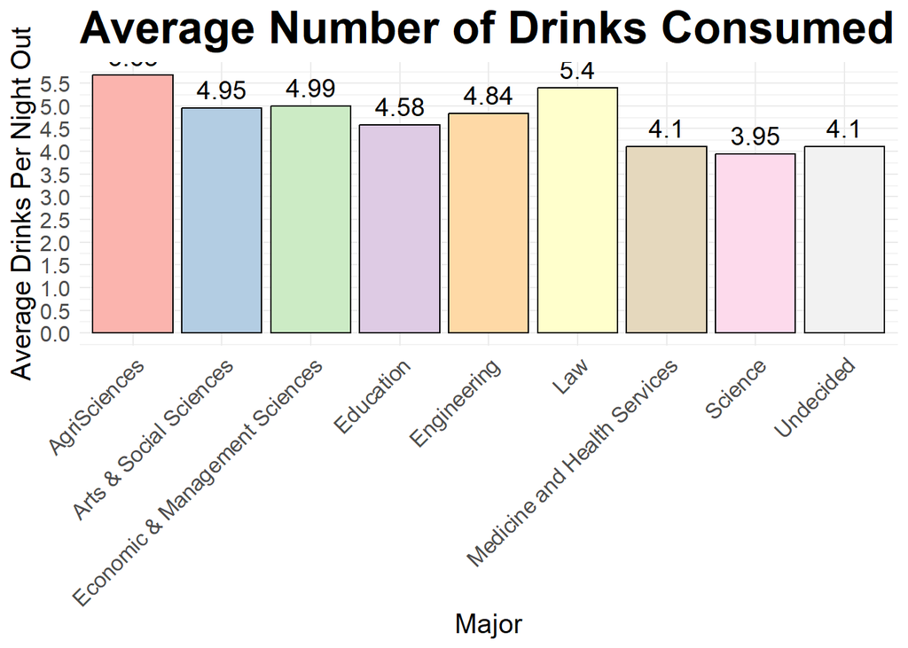

### Chart 2

**Description:**

This box plot illustrates the relationship between the average GPA of students in the year 2023 and their reported number of drinks consumed per night out.

**Reason for Choosing a box plot chart:**

A box plot is used here to show how GPA varies across different levels of alcohol consumption. It gives a clear picture of the central values, median GPA, and spread of GPA within each group of drinks per night out. This makes it easy to see if there are any patterns or differences in GPA based on how much students drink. Box plots work well for comparing a continuous variable, such as GPA, with a categorical variable, such as drinks per night out, making it easy to understand the relationship between them.

**Insights:**

Interestingly enough, in lower ranges of drinking (0-5) more drinking seems to be correlated with higher grade averages, this could be because drinking healthily could be a sign of social interaction which could lead to students helping each other. This trend doesn’t seem to continue past 5 drinks as there is a clear drop in average GPA.

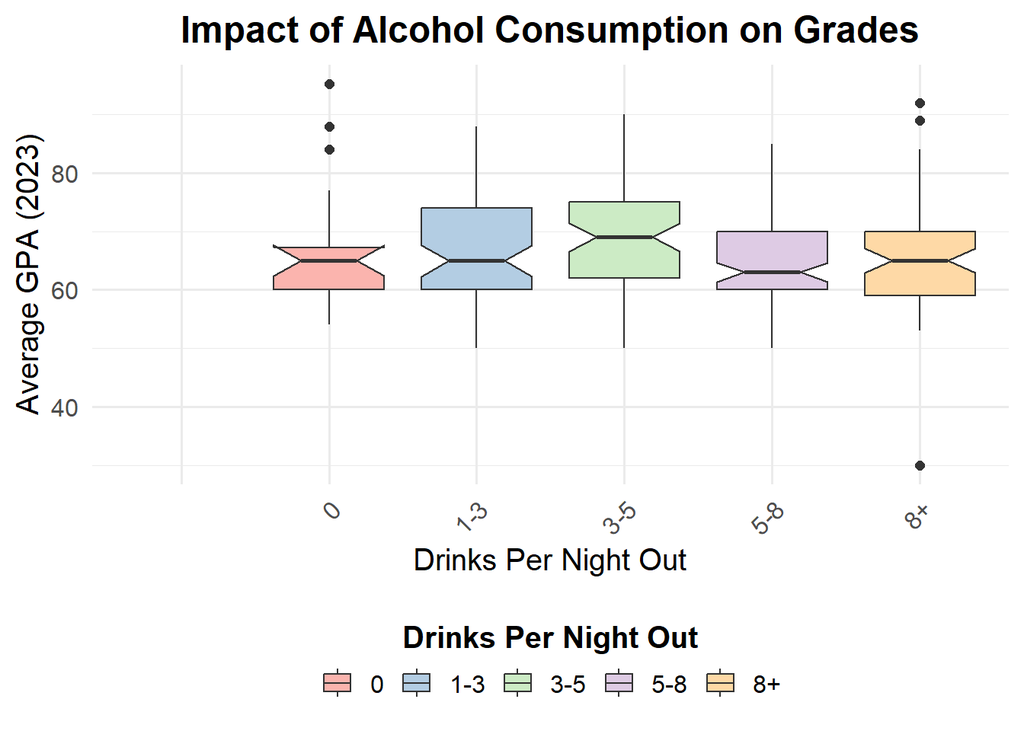

### Chart 3

**Description:**

This heat map illustrates the effect that parental relationships and attitude have on a student’s alcohol consumption

A heat map was chosen to display the data because it was the most effective option, for showing alcohol consumption in relation to both approval and relationship. Thanks to the heatmap it’s possible to see how the two variables of parental approval and parental relationship strength combine to affect student alcohol consumption.

**Insights:**

One interesting insight about the heat map is that it seems if the parent disapproves of alcohol consumption, closer relationships with parents seem to lead to higher levels of drinking. On top of that the heatmap confirms common sense in that in general, parental approval of alcohol leads to more alcohol consumption.

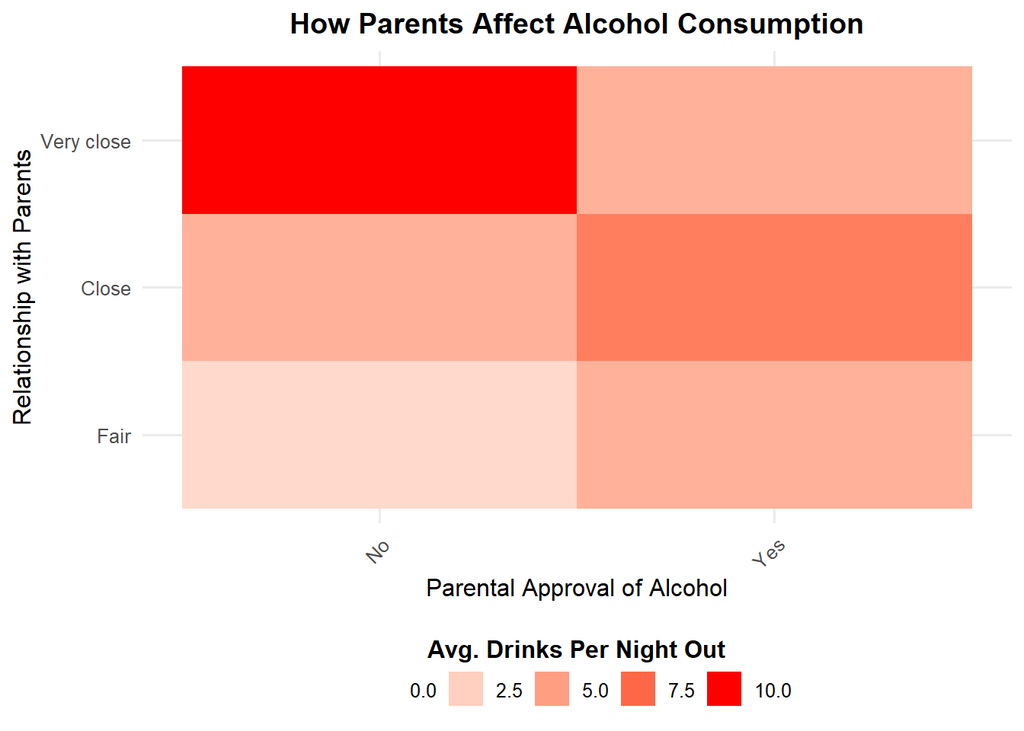